# Distributions

Website Version

Author

Affiliation

Jon Yearsley

School of Biology and Environmental Science, UCD

Published

May, 2026

**TipHow to Read this Tutorial**

This tutorial is a mixture of R code chunks and explanations of the code. The R code chunks will appear in boxes.

Below is an example of a chunk of R code:

```r
# This is a chunk of R code. All text after a # symbol is a comment
# Set working directory using setwd() function
setwd('Enter the path to my working directory')

# Clear all variables in R's memory
rm(list=ls())    # Standard code to clear R's memory
```

Sometimes the output from running this R code will be displayed after the chunk of code.

Here is a chunk of code followed by the R output

```r
2 + 4            # Use R to add two numbers
```

```
[1] 6
```

# Objectives

The objectives of this tutorial are:

1. Introduce the concept of a distribution
2. Distinguish between empirical and theoretical distributions
3. Introduce the normal distribution
4. Summarise a distribution using central tendency, spread and skew

# Introduction

To start with we will import the data from the HEIGHT.CSV file and extract just the data for females.

```r
# ************************************
# Import  data ------------------------

human <- read.table('HEIGHT.CSV', header=T, sep=',') # Import human height data
humanF <- subset(human, SEX=='Female')               # Extract data for females
```

And the data from WOLF.CSV

```r
wolf <- read.table('WOLF.CSV', header=T, sep=',')    # Import wolf data set
```

# What is a distribution?

Review this online lesson about distributions before continuing.

**NoteOnline Lesson**

[Distributions](https://DrJonYearsley.github.io/OnlineLessons/lesson3_distributions_Website.html)

This lesson is at https://DrJonYearsley.github.io/OnlineLessons/lesson3_distributions_Website.html

## Examples of distributions

### 1: Will it rain tomorrow?

The answer to this question is unknown. There are two possible outcomes: yes it will rain, no it will not rain. Although a definite answer is not possible, stating a distribution of outcomes is possible if we can estimate the probability of the two outcomes (the two probabilities must add up to one).

Below is the distribution for an estimated 70% chance of rain. This is an example of a theoretical distribution called a [**Bernoulli distribution**](https://en.wikipedia.org/wiki/Bernoulli_distribution)

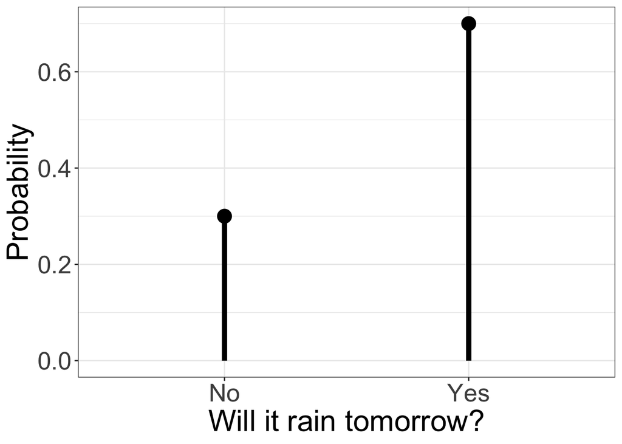

### 2: How tall is a human?

The `humanF` data shows that the heights of woman can take a range of values. The distribution of the observed data lies between 1.41 m and 1.83 m.

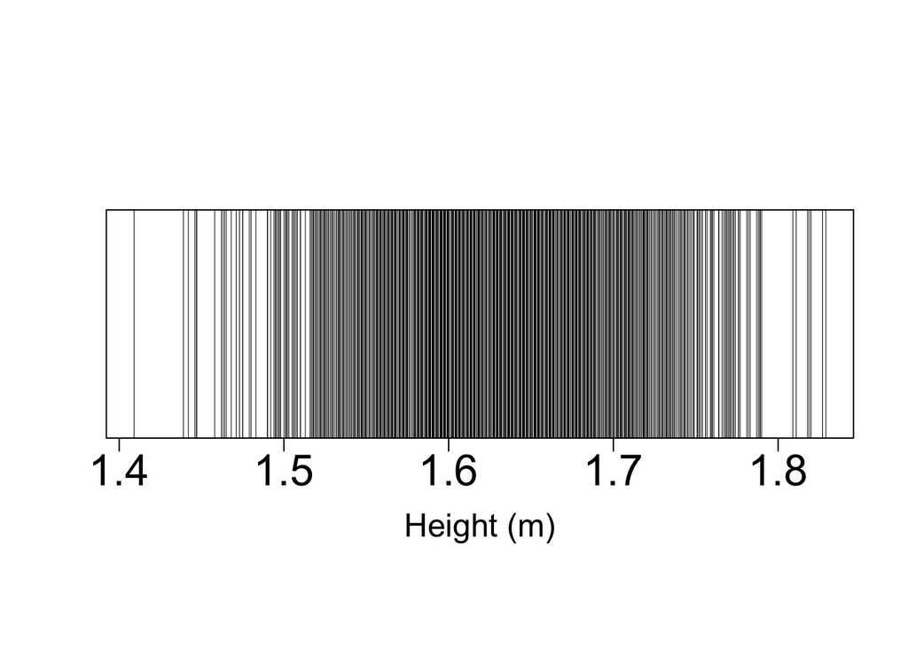

Above is a plot of the raw height data showing the distribution of the data. Each vertical line represents a data point. The data are not uniformly spread out across the entire range. There is a greater **density of data** at values in the centre of the range.

We can see the distribution of the data better using a histogram (R’s `hist()` function or `geom_histogram()` with the ggplot2 package). A histogram divides the range of heights into a number of bins and counts the number of data points in each bin.

Below is an example of a histogram with approximately 30 bins.

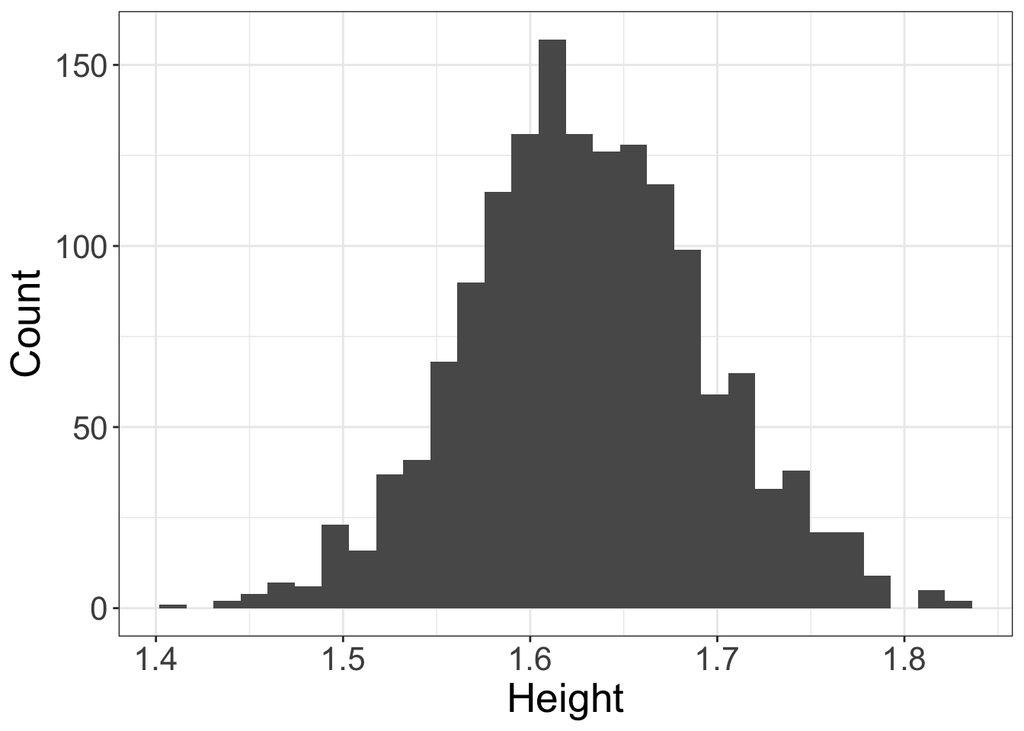

```r
# Display a histogram of female heights from the HEIGHT.CSV dataset
ggplot(data=humanF,               # Define data to be plotted
       aes(x=HEIGHT)) +
  geom_histogram(bins=30) +       # Draw a histogram using 30 bins
  labs(x='Height',y='Count') +    # Set axis titles
  theme_bw() +                    # Set background to white
  theme(axis.title = element_text(size=20),  # Set fontsize of axis title
        axis.text = element_text(size=16))  # Set fontsize of axis labels
```

The **distribution** of height is the **probability** of observing an individual of height *x* (where *x* can be any possible value).

**Values with a high probability**  
We can see that heights in the centre of the range (around 1.63 m) have the highest probability of being observed.

**Values with a low probability**  
From the histogram we can see that the probability of observing a height greater than 1.8 m is close to zero (there are 7 individuals out of 1552 with heights larger than 1.8 m).

# Visualising a distribution

Above we saw two graphical visualisations of distributions.

A distribution of a variable can be represented graphically, with a list of all the possible values of the variable on the x-axis and the relative frequency of observing each outcome (a number between 0 and 1) on the y-axis. Adding up the relative frequencies of all possible outcomes will always give a total of one, because it is 100% certain that some outcome is observed. The uncertainty is in which outcome.

The distribution of a continuous variable is sometimes called a [**probability density function**](https://en.wikipedia.org/wiki/Probability_density_function) (or PDF for short).

The distribution of a variable with a fixed number of outcomes (a qualitative variable, or a discrete quantitative variable) is sometimes called a [**probability mass function**](https://en.wikipedia.org/wiki/Probability_mass_function).

The **shape of a distribution** is best visualised using a quantile-quantile plot (QQ-plot).

**NoteOnline Lesson**

[Using QQ plots to visualise the shape of a distribution](https://DrJonYearsley.github.io/Resources/QQplots_WebVersion.html)

This lesson is at https://DrJonYearsley.github.io/Resources/QQplots_WebVersion.html

# Numerical Summary Statistics

We can start to describe any distribution by using **summary statistics** that describe some important aspects of the shape of a distribution.

Some common summary statistics are:

- **central tendency** (i.e. a value characteristic of the high probability region)
- **spread** (i.e. the ‘width’ of the high probability region)
- **skew**

### Central tendency

**NoteDefinition**

**Central tendency** is a number that aims to describe where most outcomes occur

Three common measures of central tendency are:

- the arithmetic mean (R function `mean()`)
- the median (R function `median()`)
- the mode

**NoteExample:**

Below we calculate the **median** of human height using the `median()` function

```r
# Calculate the median height, ignoring missing data
median(humanF$HEIGHT, na.rm=TRUE)
```

```
[1] 1.628
```

Notice that the median corresponds to the region of high probability in the histogram of heights (above).

### Spread

**NoteDefinition**

**Spread** is a number that aims to describe how variable the outcomes are around a central tendency

Three measures of spread are:

- the standard deviation (spread around the mean, R function `sd()`)
- the inter-quartile range (spread around the median, R function `IQR()`)
- the median absolute deviation (spread around the median, R function `mad()`)

**NoteExample:**

Below we calculate the **median absolute deviation** (MAD) of human heights using the function `mad()`

```r
# Calculate the median absolute deviation of
# height, ignoring missing data
mad(humanF$HEIGHT, na.rm=T)
```

```
[1] 0.0622692
```

### Range

**NoteDefinition**

**Range** is the difference between the largest and smallest observation in a data set

The largest and smallest observations in a data set can be calculated using the function `range()` (or by using the functions `max()` and `min()`).

**Warning**

**The max and min are not robust summary statistic of a distribution**. This is because the **max** and **min** strongly depend upon the sample size of your data set. As the sample size increases you are more likely to observed extreme values (the maximum will increase and the minimum will decrease).

Use extreme quantiles (e.g. 1% and 99% quantiles) as a more robust summary statistic of a distribution

**NoteExample:**

The maximum and minimum observed heights can be found using R’s `range()` function

```r
# Calculate the range of the data, ignoring missing data
range(humanF$HEIGHT, na.rm=TRUE)
```

```
[1] 1.409 1.829
```

A more robust measure of a distribution’s extremes are quantiles (say 1% and 99% quantiles)

**NoteExample:**

```r
# Calculate 1% and 99% quantiles, ignoring missing data
quantile(humanF$HEIGHT, prob=c(0.01, 0.99), na.rm=TRUE)
```

```
     1%     99%
1.47704 1.77896
```

# Theoretical Distributions

## The Normal distribution

The normal distribution (sometimes called a Gaussian distribution) is an extremely important **theoretical distribution** in data analysis. The distribution is completely described by two parameters:

- the mean (commonly represented by $\mu$)
- the standard deviation (commonly represented by $\sigma$)

These two parameters describe the bell shape of the normal distribution. The normal distribution is symmetric, meaning that the distribution can be reflected about the mean and look the same.

## Generating random numbers

R can generate random numbers from a specified theoretical distribution. Here are three examples.

## Normal distribution

Below is the code to generate 10,000 values with mean=2 and standard deviation=0.5.

**Note**

`rnorm()` function generates random data drawn from a normal distribution (you can specify the two parameters of the normal distribution: the mean and standard deviation).

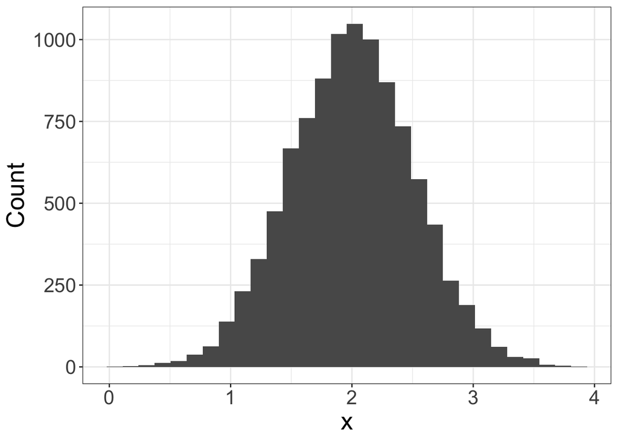

```r
# .................................................
# Generate 10000 data point drawn from a normal distribution
# .................................................


normal_data <- rnorm(n=10000, mean=2, sd=0.5)

# Produce a histogram of the generated data
ggplot(data=as.data.frame(normal_data),     # Define data to be plotted
       aes(x=normal_data)) +
  geom_histogram(bins=30) +                 # Draw a histogram using 30 bins
  labs(x='x',                               # Set axis titles
       y='Count') +
  theme_bw() +                              # Set background to white
  theme(axis.title = element_text(size=20), # Set fontsize of axis title
        axis.text =  element_text(size=16)) # Set fontsize of axis labels
```

## Binomial distribution

The binomial distribution can be used to simulate the chance of seeing a species at a location given the probability that the species exists in the habitat.

**Note**

`rbinom()` function generates the number of success given the number of attempts and the probability of a success.

Below is the code to generate the number of times a species is seen in a habitat out of 20 replicate habitats and a probability of occurrence of 0.69 (69%). This is repeated 10,000 times and the distribution from these 10,000 draws from a binomial distribution plotted.

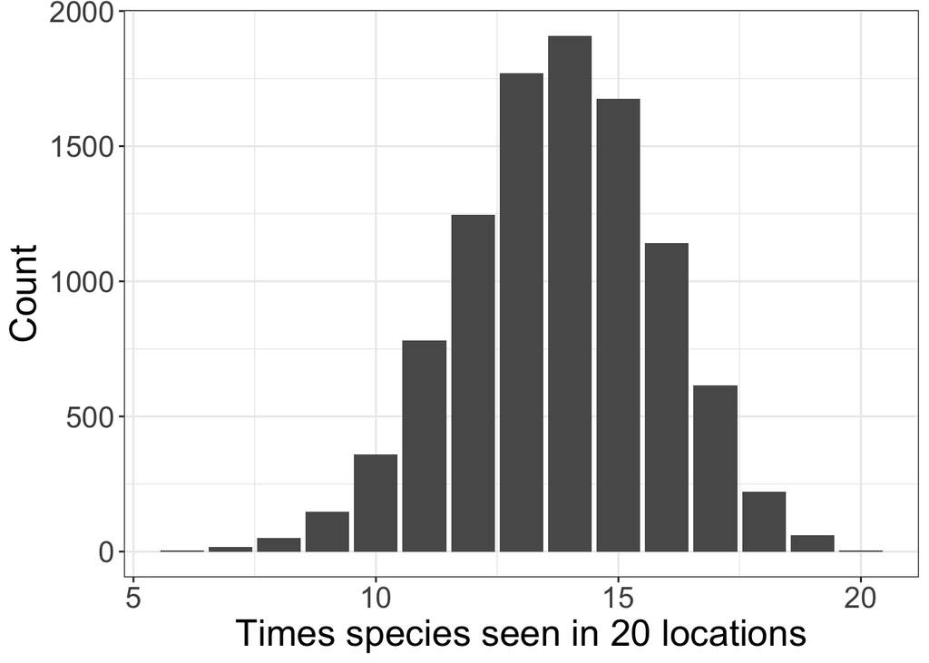

```r
# .................................................
# Generate 10000 data points drawn from a binomial distribution
# .................................................


binomial_data <- rbinom(n=10000, size=20, prob=0.69)

# Produce a histogram of the generated data
ggplot(data=as.data.frame(binomial_data),     # Define data to be plotted
       aes(x=binomial_data)) +
  geom_bar() +                                # Draw a bar plot
  labs(x='Times species seen in 20 locations',# Set axis titles
       y='Count') +
  theme_bw() +                              # Set background to white
  theme(axis.title = element_text(size=20), # Set fontsize of axis title
        axis.text =  element_text(size=16)) # Set fontsize of axis labels
```

## Categorical distribution

A categorical distribution is the relative frequencies for the levels of a qualitative variable

**Note**

`sample()` generates a random sample from a set of qualitative outcomes (e.g. picking numbers in the lottery).

Here is an example that randomly picks one day of the week

```r
# .................................................
# Generate categorical data
# .................................................

# Sample from a set of possible outcomes using sample()

# The outcomes are all the days of the week
week <- c('Monday','Tuesday','Wednesday',
         'Thursday','Friday','Saturday','Sunday')

# Sample 1 day from the week
sample(week, size=1)
```

```
[1] "Sunday"
```

We can repeat this sampling many times (70 times, say) using a for-loop

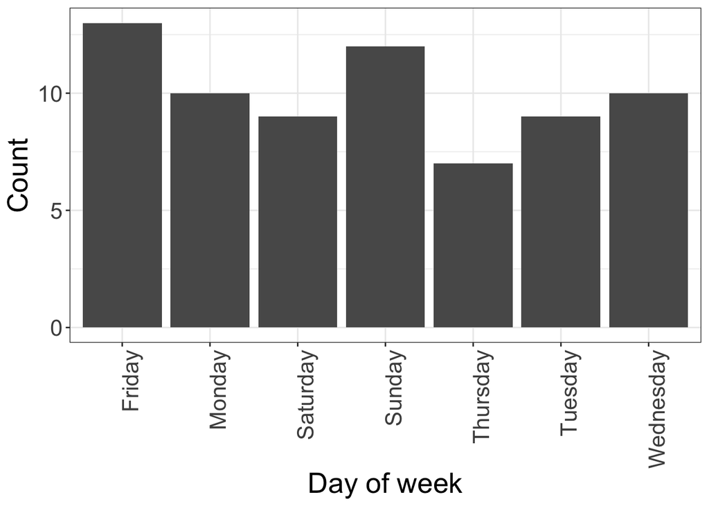

```r
# Create a blank data frame
categorical_data <- data.frame(day=rep(NA, times=70))

for (i in 1:70) {
  categorical_data$day[i] <- sample(week, size=1)
}

# Produce a histogram of the generated data
ggplot(data=categorical_data,     # Define data to be plotted
       aes(x=day)) +
  geom_bar() +                              # Draw a barplot
  labs(x='Day of week',                     # Set axis titles
       y='Count') +
  theme_bw() +                              # Set background to white
  theme(axis.title = element_text(size=20), # Set fontsize of axis title
        axis.text =  element_text(size=16), # Set fontsize of axis labels
        axis.text.x = element_text(angle=90,# Rotate x axis labels
                                   hjust=1))# Justify text
```

# Using a theoretical distribution

A theoretical distribution is used in data analysis to:

- provide a mathematical description of a random variable
- provide a distribution which can **mimic observations**
- provides a link between statistical theory and observed data

A Normal distribution is a theoretical distribution. A Normal distribution with mean = 1.63 m and standard deviation = 0.064 produces data **similar** to our observations of female heights (`humanF$HEIGHT`)

Below we have graphed histograms of the 1552 real human height observations (left) and a random sample of 1552 values drawn from a Normal distribution (right). On top of these two histograms the Normal distribution is represented as the red line (with mean = 1.63 m and standard deviation = 0.064 m).

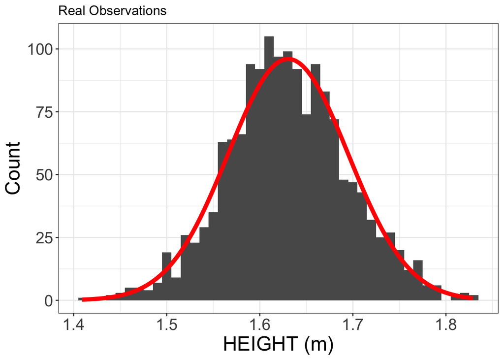

Figure: A histogram visualising the distribution of 1552 real observations of human heights. The red line represents a normal distribution with the same central tendency and spread as the observations

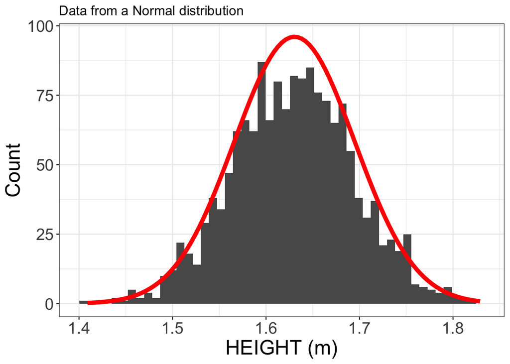

Figure: A histogram visualising the distribution of 1552 simulated data points that have been drawn from a normal distribution (red curve).

# Summary of topics

- A distribution describes all possible outcomes and their relative frequencies
- A measure of central tendency (e.g. median, mean) and a measure of spread (e.g. median absolute deviation, standard deviation) are descriptive statistics that start to describe a distribution
- A histogram and quantile-quantile plot can be used to visualise a distribution
- The normal distribution is the single most important theoretical distribution in data analysis
- The normal distribution is completely described by two parameters: mean and standard deviation
- Normal data can be generate in R using the `rnorm()` function
- Categorical data can be generated using the `sample()` function

# Further Reading

All these books can be found in UCD’s library

- Mark Gardner, 2012 **Statistics for Ecologists Using R and Excel** (Pelagic, Exeter) [Chapter 4]
- Tenko Raykov and George A Marcoulides, 2013 **Basic statistics: an introduction with R** (Rowman and Littlefield, Plymouth)
- John Verzani, 2005 **Using R for introductory statistics** (Chapman and Hall, London)